# Perspectives on Computational Modeling: Problem Set #8

## Part 2: Modeling voter turnout

Models description: In this part, the response variable would be `vote96`, and the predictors would be all the other variables: `mhealth_sum`, `age`, `educ`, `black`, `female`, `married` and `inc10`.

### Preparation

The data is splitted into a training set (70%) and a validation set (30%) as required.

### 1. Five tree-based models of voter turnout

#### 1.1 classification tree with optimal level of complexity

Using a 10-fold CV with random seed = 1234, I decide that the optimal tree size is 7. When the complexity reaches 7, the test MSE obtains nearly its lowest point among the attempts. In addition, since simply increasing the complexity could cause over-fitting problem, I would not increase the tree size to numbers that would not contribute much to further lower the test MSE.

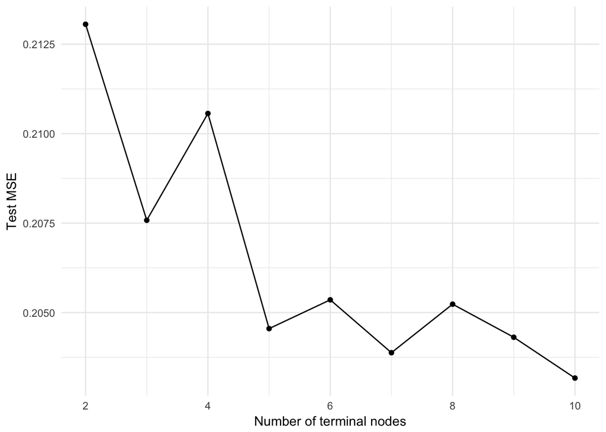

```
##
## Classification tree:
## snip.tree(tree = mhlth_tree, nodes = c(18L, 11L, 6L, 19L, 8L,
## 7L, 10L))
## Variables actually used in tree construction:
## [1] "mhealth_sum" "age"         "educ"
## Number of terminal nodes:  7
## Residual mean deviance:  1.05 = 846 / 809
## Misclassification error rate: 0.287 = 234 / 816
```

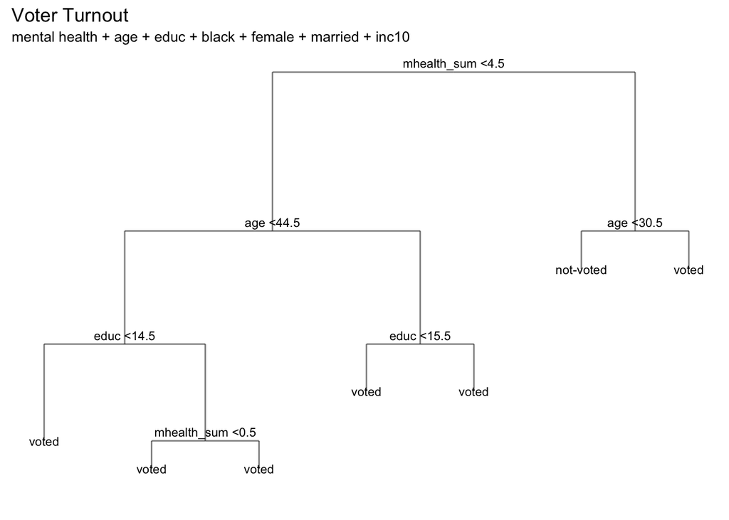

The RPC curve is shown as below.

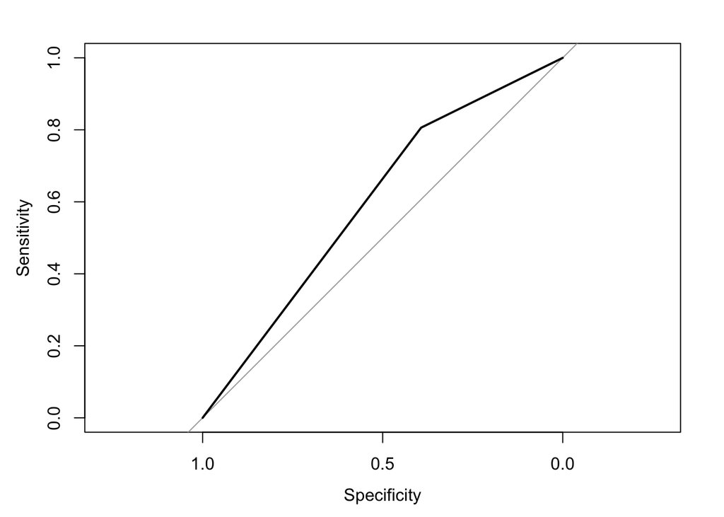

```
## Area under the curve: 0.6
```

#### 1.2: Bagging approach

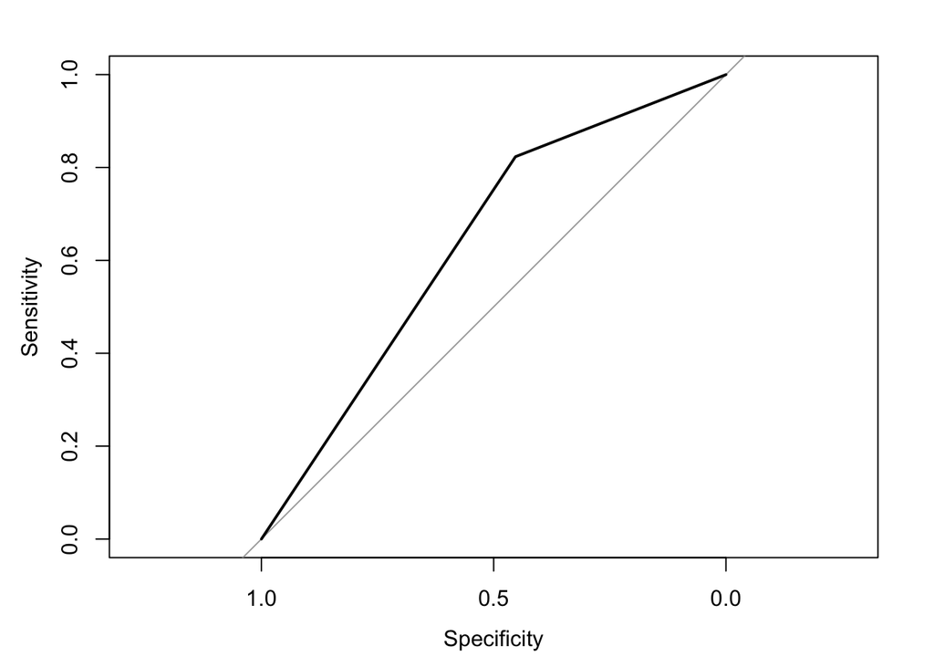

```
## Area under the curve: 0.638
```

#### 1.3 Random forest approach

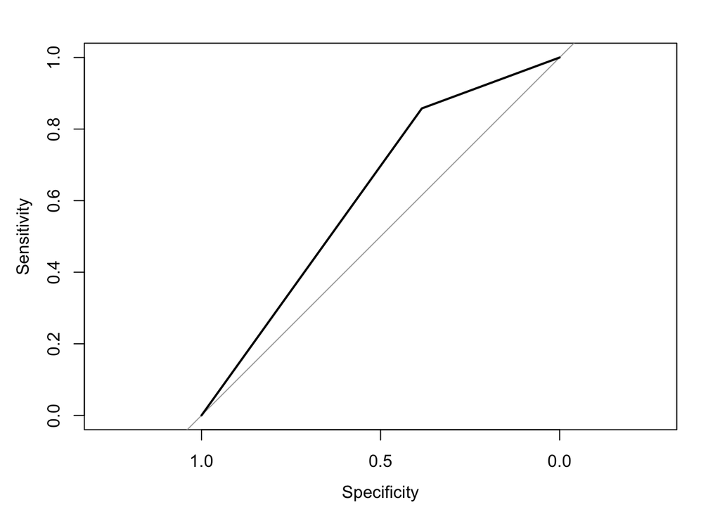

```
## Area under the curve: 0.621
```

#### 1.4 single-predictor classification tree with optimal level of complexity

The single predictor is `mhealth_sum`. According to the 10-fold cross-validation, the optimal level of complexity is 4.

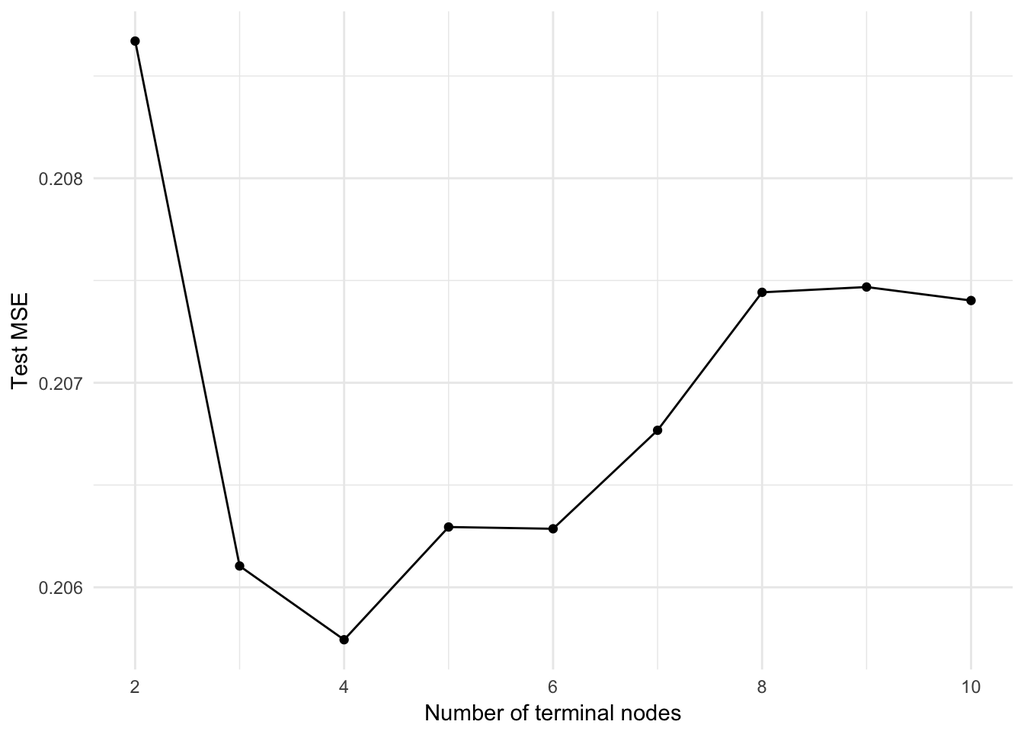

```
##
## Classification tree:
## snip.tree(tree = mhlth_tree2, nodes = 7L)
## Number of terminal nodes:  4
## Residual mean deviance:  1.18 = 955 / 812
## Misclassification error rate: 0.284 = 232 / 816
```

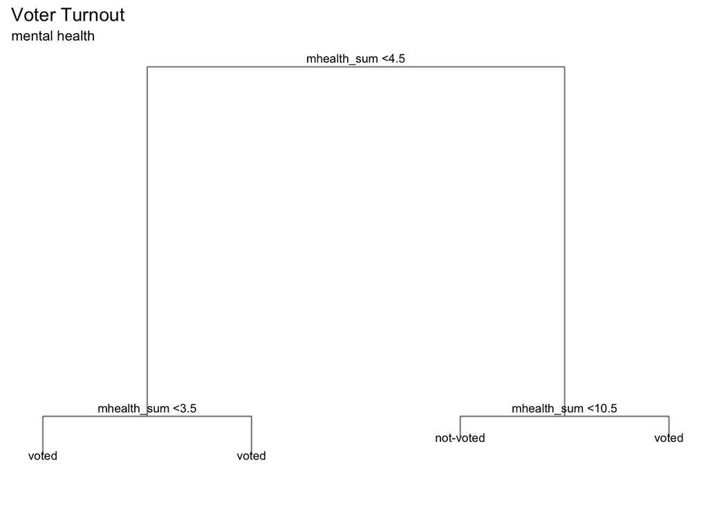

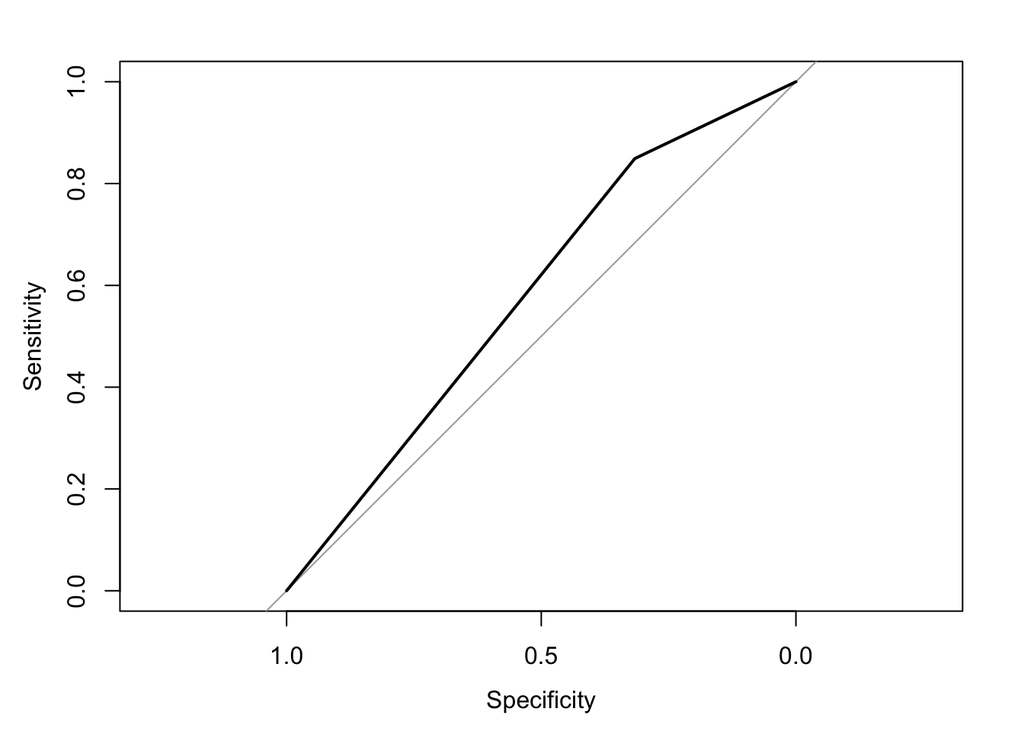

```
## Area under the curve: 0.583
```